# M5A1AgustinCervantesTenaglia

Agustin Cervantes

`07.02.2024`

# EJERCICIO 1 (2 puntos)

La compañía telefónica LEMON va a realizar una campaña comercial el día de Black Friday para conseguir nuevos clientes. En base a su experiencia anterior, sabe que una de cada 25 personas que reciben una llamada publicitaria acaban contratando un producto de telefonía móvil y una de cada 100 personas un producto de telefonía + TV. Si en un día 2000 personas recibieron una llamada:

## a) Describir las variables aleatorias que modelizan ambos fenómenos.

Se pueden definir dos variables aleatorias:

Contratación de telefonía móvil: Es una variable aleatoria discreta binomial que representa el número de personas que recibieron una llamada publicitaria y decidieron contratar un producto de telefonía móvil. La función es binomial, donde n es la cantidad de llamadas que se realicen y p es la probabilidad de que lo contraten. La probabilidad de contratación = 1/25

Contratación de telefonía + TV: Es una variable aleatoria discreta binomial Representa el número de personas que recibieron una llamada publicitaria y decidieron contratar un producto que incluye telefonía móvil y TV. La función es binomial, donde n es la cantidad de llamadas y p es la probabilidad de que contraten el servicio. La probabilidad de que lo contraten es de 1/100.

Se definen las variables que se utilizarán para los cálculos:

```r
n_llamadas <- 2000
prob_movil <- 1/25
prob_tv <- 1/100
```

## b) Hallar la probabilidad de que el número de personas que contraten un producto de telefonía móvil sea 150.

```r
ventas_movil <- dbinom(150, n_llamadas, prob_movil)
print(ventas_movil)
```

```
## [1] 2.623829e-13
```

La probabilidad de que se contraten exactamente 150 servicios es cercana a 0.

## c) Hallar la probabilidad de que el número de personas que contraten un producto de telefonía TV sea superior a 100.

```r
ventas_TV <- (1 - pbinom(100, n_llamadas, prob_tv))
print(ventas_TV)
```

```
## [1] 0
```

La probabilidad de que se contraten exactamente más de 100 servicios es cercana a 0.

# EJERCICIO 2 (2 puntos)

Se espera que el número de segundos que los usuarios dedican a rellenar un determinado formulario en la web se distribuye según una ley normal de media 155 s. Se toma una muestra de 10 usuarios, y se mide el tiempo que dedican al formulario. Los resultados fueron: 133, 159, 145, 150, 153, 163, 138, 158, 139, 146, 150, 175, 200 Contrastar la hipótesis de que esta muestra proviene de una población con media 155 segundos a un nivel de confianza de 90%, 95% y 99%.

```r
#Creo los dos objetos que utilizaré para el contraste de hipotesis:
muestra_usuarios <- c(133, 159, 145, 150, 153, 163, 138, 158, 139, 146, 150, 175, 200)
valor_hipotesis_nula <- 155
```

## Realizo la prueba para cada nivel de confianza:

### 1. Para el nivel de confianza 90%:

```r
t.test(muestra_usuarios, mu = valor_hipotesis_nula, conf.level = 0.90)
```

```
##
##  One Sample t-test
##
## data:  muestra_usuarios
## t = -0.093821, df = 12, p-value = 0.9268
## alternative hypothesis: true mean is not equal to 155
## 90 percent confidence interval:
##  145.7707 163.3062
## sample estimates:
## mean of x
##  154.5385
```

Los resultados nos muestran: p-value = 0.9268 por lo cual no es posibile descartar la hipótesis nula dado que supera el nivel de significancia 0.10. El intervalo de confianza del nivel 90% es: 145.7707 - 163.3062

### 2. Para el nivel de confianza 95%:

```r
t.test(muestra_usuarios, mu = valor_hipotesis_nula, conf.level = 0.95)
```

```
##
##  One Sample t-test
##
## data:  muestra_usuarios
## t = -0.093821, df = 12, p-value = 0.9268
## alternative hypothesis: true mean is not equal to 155
## 95 percent confidence interval:
##  143.8201 165.2568
## sample estimates:
## mean of x
##  154.5385
```

Los resultados nos muestran: p-value = 0.9268 por lo cual no es posibile descartar la hipótesis nula dado que supera el nivel de significancia 0.05. El intervalo de confianza del nivel 95% es: 143.8201 - 165.2568

### 3. Para el nivel de confianza 99%:

```r
t.test(muestra_usuarios, mu = valor_hipotesis_nula, conf.level = 0.99)
```

```
##
##  One Sample t-test
##
## data:  muestra_usuarios
## t = -0.093821, df = 12, p-value = 0.9268
## alternative hypothesis: true mean is not equal to 155
## 99 percent confidence interval:
##  139.5121 169.5649
## sample estimates:
## mean of x
##  154.5385
```

## Conclusión:

Con los datos proporcionados y los niveles de confianza especificados, no se puede afirmar que la muestra provenga de una población con una media diferente de 155 segundos, dado que los intervalos de confianza para la media incluyen el mencionado valor.

# EJERCICIO 3 (3 puntos)

Dado el conjunto de datos supermarket_sales.csv donde cada registro es un producto vendido, se pide:

Previo a realizar los ejercicios analizo el conjunto de datos proporcionado:

```r
conjunto_datos <- read.csv("C:\\Users\\aguce\\Downloads\\supermarket_sales.csv", sep = ";")
head(conjunto_datos)
```

```
##    Invoice.ID Branch      City Customer.type Gender           Product.line
## 1 750-67-8428      A    Yangon        Member Female      Health and beauty
## 2 226-31-3081      C Naypyitaw        Normal Female Electronic accessories
## 3 631-41-3108      A    Yangon        Normal   Male     Home and lifestyle
## 4 123-19-1176      A    Yangon        Member   Male      Health and beauty
## 5 373-73-7910      A    Yangon        Normal   Male      Sports and travel
## 6 699-14-3026      C Naypyitaw        Normal   Male Electronic accessories
##   Unit.price      Date  Time     Payment
## 1      74,69  1/5/2019 13:08     Ewallet
## 2      15,28  3/8/2019 10:29        Cash
## 3      46,33  3/3/2019 13:23 Credit card
## 4      58,22 1/27/2019 20:33     Ewallet
## 5      86,31  2/8/2019 10:37     Ewallet
## 6      85,39 3/25/2019 18:30     Ewallet
```

Del análisis del conjunto de datos, podemos ver que se trata de un listado de ventas realizadas por un comercio retail, con 1000 observaciones y 10 variables. Entre las variables vemos:

- ID: que pareciera ser el número de factura o venta, es único.
- City: ciudad en donde se realizó la venta.
- Customer type: hay dos tipos, Member o Normal, por lo cual inferimos que se trata de un tipo de cliente.
- Gender: el género del comprador.
- Product line: el tipo de producto al que pertenece el objeto comprado.
- Unit price: el precio del objeto vendido.
- Date y Time: dia y hora de la compra.
- Payment: método de pago utilizado.

### a) Tabla de frecuencia del número de ventas por ciudad

Para hacer este resumen de datos, utilizo un análisis univariante de frecuencia absoluta:

```r
frec_city <- table(conjunto_datos$City)
print(frec_city)
```

```
##
##  Mandalay Naypyitaw    Yangon
##       332       328       340
```

### b) Tabla de frecuencias del número de ventas por ciudad y género

Para la tabla de frecuencia de dos variables, genero una tabla dinámica en Excel que muestre las ventas por ciudad y por género:

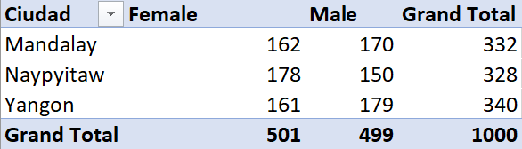

### c) Ciudad con menor cantidad de productos vendidos

Ordeno la tabla de ciudad por cantidad de ventas de menor a mayor. De esta manera, vemos que la ciudad con menor cantidad de productos vendidos es “Naypyitaw” con 328 ventas:

```r
menor_qvendidos_ordenados <- sort(frec_city, ascending = TRUE)
head(menor_qvendidos_ordenados,1)
```

```
##
## Naypyitaw
##       328
```

### d) Ciudad con menor ingreso (€)

Para obtener el la ciudad con menor ingreso utilizo una tabla dinámica en Excel y la ordeno por monto de ingreso. La ciudad con menor ingreso es Mandalay:

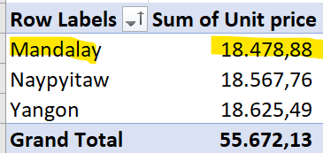

### e) Tipo de producto más vendido cuando la compra se ha realizado mediante EWallet

Utilizo la tabla dinámica filtrando por “Ewallet”, agrupando con “Product line” y sumando los valores de las ventas. Al ordenarlo de menor a mayor, identificamos que el tupo de producto “Fashion accesories” es el más vendido en cuanto a cantidad de productos:

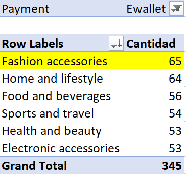

### f) Mes con mayores ventas

Previo a poder armar la tabla dinámica, reformateo la fecha para convertirla en el formato europeo. Luego lo agrupo por mes y ordeno, verificando que en Enero es donde se han hecho más ventas:

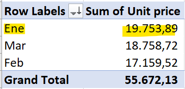

# EJERCICIO 4 (1.5 puntos)

Supongamos que eres un analista de datos en una empresa de marketing y estás trabajando con un conjunto de datos que contiene información sobre el gasto en publicidad (en miles de dólares) y las ventas generadas por un producto en particular (en miles de unidades). El objetivo es desarrollar un modelo de regresión lineal para predecir las ventas en función del gasto en publicidad. Datos del modelo ajustado:

Coeficiente de intersección: β_0=9

Coeficiente del gasto en publicidad: β_1=4.2

### a) Utilizando los coeficientes del modelo, predice las ventas esperadas para un mes en el que la empresa gaste 35.000$ en publicidad.

La función de regresión es la siguiente:

Variable = Coeficiente de intersección + Coeficiente del Gasto de pubicidad x Gasto de publicidad

```r
coef_inter <- 9
coef_gasto <- 4.2

resultado.a <- (coef_inter + coef_gasto*35000)

print(resultado.a)
```

```
## [1] 147009
```

### b) ¿Qué podrías decir sobre la bondad de ajuste del modelo si la empresa tuvo un mes en el que gastó 22000$ en publicidad y las ventas reales fueron 100000$?

```r
coef_inter <- 9
coef_gasto <- 4.2

resultado.b <- (coef_inter + coef_gasto*22000)

print(resultado.b)
```

```
## [1] 92409
```

La diferencia con lo estimado es de 7.591, por lo tanto, el valor a sido de 8,21% por encima del esperado. Esto implica que es un modelo con error relativamente alto y dependerá del tipo de negocio y riesgo a asumir por quienes realizan la estimación, si lo consideran como válido o no.

### c) Si la empresa aumenta su gasto en publicidad en 1000$, ¿cuánto se espera que aumenten las veta según el modelo?

```r
coef_inter <- 9
coef_gasto <- 4.2

resultado.c <- (coef_inter + coef_gasto*1000)

print(resultado.c)
```

```
## [1] 4209
```

# EJERCICIO 5 (1.5 puntos)

Supongamos que estás trabajando en un proyecto de investigación médica y estás interesado en desarrollar un modelo para predecir la probabilidad de cura de una enfermedad con base en diferentes variables relacionadas con el paciente: edad, duración de la enfermedad y nivel de gravedad de los síntomas. Utilizando el siguiente árbol de regresión para abordar este problema:

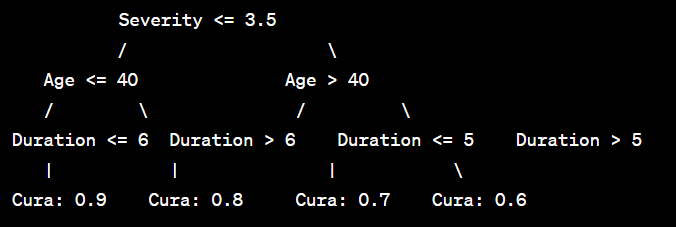

*Rama izquierda = Sí; Rama derecha = No

### a) Si un paciente tiene síntomas de gravedad 2, tiene menos de 40 años y ha estado enfermo durante 10 meses, ¿cuál es la probabilidad de cura según el modelo?

Según el modelo representado, la probabilidad de cura es de 0.8 (o 80%)

### b) ¿Qué implica para un paciente si la probabilidad de cura es 0.8 según el modelo?

De acuerdo al modelo, un paciente que tiene 0.8 de probabilidad de cura, significa que tendría un 80% de probabilidad de curarse de la enfermedad. En este caso, quienes tienen esa probabilidad de cura o mayor, son los que tienen un nivel de severidad de la enfermedad menor a 3.5 y son menores de 40 años.

### c) Caracteriza (3 características) a dos pacientes cuya probabilidad de cura es 0.6

Dos ejemplos de pacientes que tienen una probabilidad de cura de 0.6 podrían ser: Paciente 1: Severidad de la enfermedad de 3.6 > Edad de 52 años > Duración de la enfermedad de 10 meses.

Paciente 2: Severidad de la enfermedad de 4 > Edad de 60 años > Duración de la enfermedad de 7 meses.